# NYPD Shooting Incident Data

C.Ifill

2025-01-18

## Dataset

The data we will be looking into today is the list of identified NYPD shooting incidents from 2006 up to 2023. The data can be retrieved from this file: https://data.cityofnewyork.us/api/views/833y-fsy8/rows.csv?accessType=DOWNLOAD

```r
library(tidyverse)
library(dplyr)
library(randomForest)
#pull the flat file for analysis
nypd_data <- read_csv("https://data.cityofnewyork.us/api/views/833y-fsy8/rows.csv?accessType=DOWNLOAD")
#remove unnecessary columns
nypd_data <- nypd_data %>%
  select(-(X_COORD_CD : Lon_Lat),-INCIDENT_KEY, -LOC_OF_OCCUR_DESC, -LOC_CLASSFCTN_DESC, -LOCATION_DESC)

#format the OCCUR_DATE into date
nypd_data$OCCUR_DATE <- mdy(nypd_data$OCCUR_DATE)

#create two new columns called year and week, both based on OCCUR_DATE
nypd_data <- nypd_data %>%
  mutate(occur_year = format(OCCUR_DATE, "%Y")) %>%
  mutate(occur_week = week(OCCUR_DATE))

#create vector of columns to reformat and convert them to factors
to_factor <- c("BORO", "PRECINCT", "PERP_AGE_GROUP", "PERP_SEX", "PERP_RACE","VIC_AGE_GROUP", "VIC_SEX", "VIC_RACE", "occur_year", "occur_week")
nypd_data[to_factor] <- lapply(nypd_data[to_factor], factor)
```

Here is a summary of the data:

```r
summary(nypd_data)
```

```
##    OCCUR_DATE          OCCUR_TIME                  BORO          PRECINCT
##  Min.   :2006-01-01   Length:28562      BRONX        : 8376   75     : 1628
##  1st Qu.:2009-09-04   Class1:hms        BROOKLYN     :11346   73     : 1500
##  Median :2013-09-20   Class2:difftime   MANHATTAN    : 3762   67     : 1259
##  Mean   :2014-06-07   Mode  :numeric    QUEENS       : 4271   44     : 1076
##  3rd Qu.:2019-09-29                     STATEN ISLAND:  807   79     : 1045
##  Max.   :2023-12-29                                           47     : 1006
##                                                               (Other):21048
##  JURISDICTION_CODE STATISTICAL_MURDER_FLAG PERP_AGE_GROUP   PERP_SEX
##  Min.   :0.0000    Mode :logical           18-24  :6438   (null): 1141
##  1st Qu.:0.0000    FALSE:23036             25-44  :6041   F     :  444
##  Median :0.0000    TRUE :5526              UNKNOWN:3148   M     :16168
##  Mean   :0.3219                            <18    :1682   U     : 1499
##  3rd Qu.:0.0000                            (null) :1141   NA's  : 9310
##  Max.   :2.0000                            (Other): 768
##  NA's   :2                                 NA's   :9344
##           PERP_RACE     VIC_AGE_GROUP   VIC_SEX
##  BLACK         :11903   <18    : 2954   F: 2760
##  WHITE HISPANIC: 2510   1022   :    1   M:25790
##  UNKNOWN       : 1837   18-24  :10384   U:   12
##  BLACK HISPANIC: 1392   25-44  :12973
##  (null)        : 1141   45-64  : 1981
##  (Other)       :  469   65+    :  205
##  NA's          : 9310   UNKNOWN:   64
##                            VIC_RACE       occur_year      occur_week
##  AMERICAN INDIAN/ALASKAN NATIVE:   11   2006   : 2055   27     :  939
##  ASIAN / PACIFIC ISLANDER      :  440   2021   : 2011   25     :  793
##  BLACK                         :20235   2008   : 1959   35     :  787
##  BLACK HISPANIC                : 2795   2020   : 1948   26     :  785
##  UNKNOWN                       :   70   2011   : 1939   31     :  742
##  WHITE                         :  728   2010   : 1912   32     :  742
##  WHITE HISPANIC                : 4283   (Other):16738   (Other):23774
```

### Missing/Erroneous Data

There was one instance in the data where the victim’s age was 1022. I assumed it was a typo and removed it from the data.

There are missing values from perp’s race, age and sex. I decided to leave those values as it may be that the perpetrators we never identified.

The missing values in victim’s sex and age were removed. The data may be missing/unknown as a body was never recovered, but reason for unknown is not pertinent. I left the missing values victim’s race as it may be difficult to determine on a corpse.

```r
#remove unwanted rows: erroneous and missing data
nypd_data <- nypd_data %>% filter(!VIC_AGE_GROUP %in% c('1022'), !VIC_SEX %in% c('U'), !VIC_AGE_GROUP %in% c('UNKNOWN'))
```

## Visuals

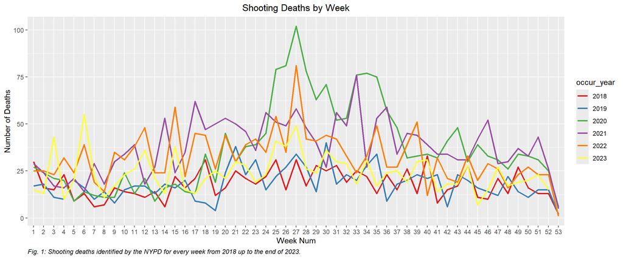

```r
#create dataframe week_year_count that is a summary of the original data but count the deaths by week by year
Week_year_counts <- nypd_data %>%
  filter(as.numeric(format(OCCUR_DATE, "%Y")) <= as.numeric(max(format(OCCUR_DATE, "%Y"))) & as.numeric(format(OCCUR_DATE, "%Y")) >= as.numeric(max(format(OCCUR_DATE, "%Y")))-5) %>%
  group_by(occur_year, occur_week) %>%
  count()

#plot week_year_counts for 2018 to 2023
ggplot(Week_year_counts, aes(x = occur_week, y = n, group = occur_year, colour = occur_year)) +
  geom_line(linewidth = 1) +
  ggtitle("Shooting Deaths by Week") +
  xlab("Week Num") +
  ylab("Number of Deaths") +
  scale_color_brewer(palette="Set1") +
  labs(caption = "Fig. 1: Shooting deaths identified by the NYPD for every week from 2018 up to the end of 2023.", fill = "Year") +
  theme(plot.caption.position = "panel", plot.caption = element_text(hjust = 0, size = "9", colour = "black", face = "italic"), plot.title = element_text(hjust = 0.5))
```

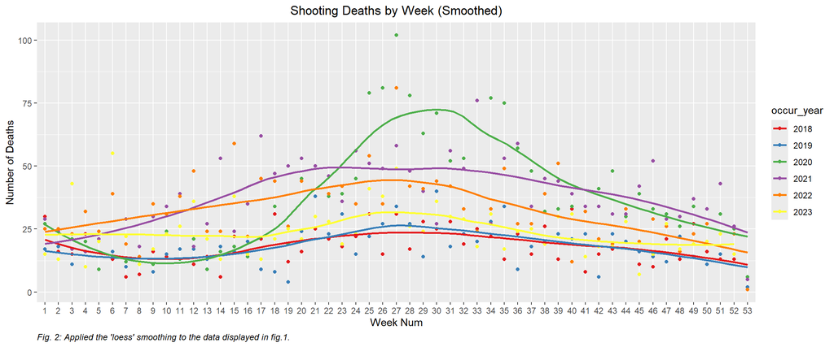

```r
#add a loess curve to the previous line graph
ggplot(Week_year_counts, aes(x = occur_week, y = n, group = occur_year, colour = occur_year)) +
  geom_point() +
  geom_smooth(se = FALSE, span = 0.6) +
  ggtitle("Shooting Deaths by Week (Smoothed)") +
  xlab("Week Num") +
  ylab("Number of Deaths") +
  scale_color_brewer(palette="Set1") +
  labs(caption = "Fig. 2: Applied the 'loess' smoothing to the data displayed in fig.1.", fill = "Year") +
  theme(plot.caption.position = "panel", plot.caption = element_text(hjust = 0, size = "9", colour = "black", face = "italic"), plot.title = element_text(hjust = 0.5))
```

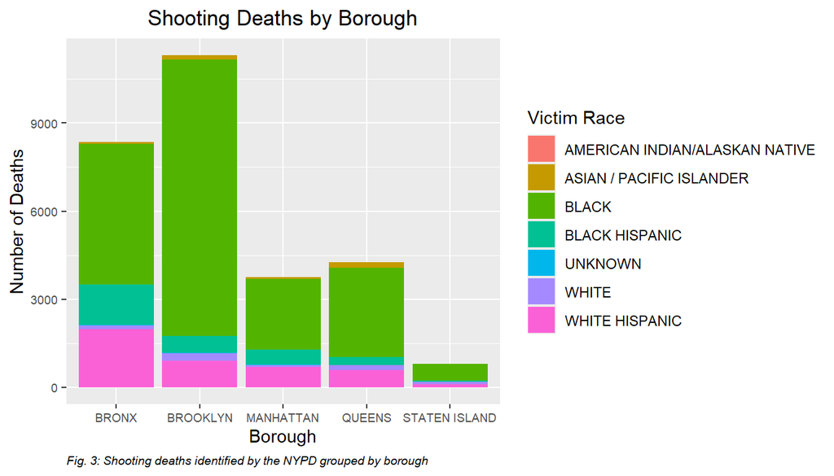

```r
#create new dataframe that groups original data by victim race
race_spread_vic <- nypd_data %>%
  group_by(VIC_RACE) %>%
  count() %>%
  ungroup() %>%
  mutate(perc = `n` / sum(`n`)) %>%
  arrange(perc) %>%
  mutate(labels = scales::percent(perc))

#plot a bar graph of the deaths by race by borough
ggplot(nypd_data, aes(x = BORO, fill = VIC_RACE)) +
  geom_bar() +
  ggtitle("Shooting Deaths by Borough") +
  xlab("Borough") +
  ylab("Number of Deaths") +
  guides(fill = guide_legend(title = "Victim Race")) +
  labs(caption = "Fig. 3: Shooting deaths identified by the NYPD grouped by borough") +
  theme(axis.text=element_text(size=7), plot.caption.position = "panel", plot.caption = element_text(hjust = 0, size = "7", colour = "black", face = "italic"), plot.title = element_text(hjust = 0.5))
```

```r
#return the values for the deaths in the Bronx and Brooklyn boroughs
bronx_vics <- nypd_data %>%
  filter(BORO == "BRONX") %>%
  count()

brook_vics <- nypd_data %>%
  filter(BORO == "BROOKLYN") %>%
  count()

#return the single value for the overall percentage of black victims
vic_black_perc <- round(race_spread_vic$perc[race_spread_vic$VIC_RACE == "BLACK"]*100,0)
```

## Model and Analysis

```r
#create dataframe that groups original data by occurrence year and provides the volume and percentage of deaths
deathsBy_year <- nypd_data %>%
  group_by(occur_year) %>%
  count( name = "Volume") %>%
  ungroup() %>%
  mutate(deci = `Volume` / sum(`Volume`)) %>%
  arrange(deci) %>%
  mutate(Percentage = scales::percent(deci)) %>%
  select(-deci) %>%
  arrange(occur_year)

#create dataframe that groups original data by victims' sex and provides the volume and percentage of deaths
deathsBy_sex <- nypd_data %>%
    group_by(VIC_SEX, VIC_AGE_GROUP) %>%
    count() %>%
    ungroup() %>%
    mutate(deci = `n` / sum(`n`)) %>%
    arrange(deci) %>%
    mutate(Percentage = scales::percent(deci))
```

However, taking count of all the years available in the dataset:

```r
#put deaths_by_year into a simple table format
knitr::kable(deathsBy_year, "simple")
```

| occur_year | Volume | Percentage |
| --- | --- | --- |
| 2006 | 2050 | 7.1953% |
| 2007 | 1877 | 6.5880% |
| 2008 | 1955 | 6.8618% |
| 2009 | 1824 | 6.4020% |
| 2010 | 1910 | 6.7039% |
| 2011 | 1930 | 6.7741% |
| 2012 | 1712 | 6.0089% |
| 2013 | 1335 | 4.6857% |
| 2014 | 1457 | 5.1139% |
| 2015 | 1433 | 5.0297% |
| 2016 | 1202 | 4.2189% |
| 2017 | 970 | 3.4046% |
| 2018 | 955 | 3.3519% |
| 2019 | 963 | 3.3800% |
| 2020 | 1947 | 6.8337% |
| 2021 | 2010 | 7.0549% |
| 2022 | 1714 | 6.0159% |
| 2023 | 1247 | 4.3768% |

We can identify that the volume of 2017-2019 were actually the low years compared to years preceding. If anything, the shooting deaths were returning to a more regular volume. I would be very interesting to further investigate what occurred in 2017-2019 that influenced the data.

Grouping the shooting by the sex of the victims, we see an overwhelming 90% of victims were male. 46% of the victims were in the 25-44 age group regardless of gender.

Per fig 3, we see the two worst boroughs are the Bronx and Brooklyn (8,357 and 11,317 respectively), and a significant portion of the overall victims (approximately 71%) were identified as Black.

I applied the Random Forest model to the 2023 data and used the week number, borough, victim age group and victim race as features to predict the volume of deaths by week. The following is the predicted data (in red) compared to the true data (blue):

```r
#filter the original data for 2023 only and provide the death volume by week
deathsBy_week_2023 <- nypd_data %>%
  filter(occur_year == "2023") %>%
  group_by(occur_week, BORO, VIC_AGE_GROUP, VIC_RACE) %>%
  count( name = "volume")

#ensure the data is reproducible and create the random forest model
set.seed(1)

model <- randomForest( formula = volume ~ ., data = deathsBy_week_2023)

deathsBy_week_2023$pred <- predict(model)

#re-apply the group-by to the deathsBy_week for easier model comparison
deathsBy_week_2023 <- deathsBy_week_2023 %>%
  group_by(occur_week) %>%
  summarise(volume_val = sum(volume), pred_val = sum(pred))
```

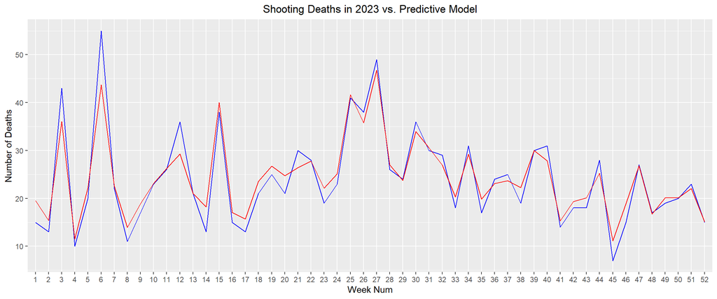

```r
#plot the comparison or predictions vs actuals
deathsBy_week_2023 %>% ggplot() +
  geom_line(aes(x = occur_week, y = volume_val, , group = 1), colour = "blue") +
  geom_line(aes(x = occur_week, y = pred_val, group = 1), colour = "red") +
  ggtitle("Shooting Deaths in 2023 vs. Predictive Model") +
  xlab("Week Num") +
  ylab("Number of Deaths") +
  theme(plot.title = element_text(hjust = 0.5))
```

## Identified Biases and Conclusion

The first and immediately identifiable bias I encountered was wanting to focus only on the ethnicity and age group I belong to. I wanted to know more about the other me, the imaginary me in the victims. I avoided that by sticking to the general stats, giving a little bit of everything so that my follow-up questions would not be based on one group and I found myself asking questions I would not have thought of had I followed my original plan. this is **Group Attribution Bias**

Before the data even comes to me, it may already contain biases:

- **Selection Bias**: If a certain precinct has more consistent death reporting, it may skew the data towards them or the area they patrol.
- **Overgeneralization Bias**: Population information, like if a certain area only has one ethnicity, we can’t conclude based only on the data that the other ethnicities are “safe”.

We cannot know based on the data alone what is the cause for the deaths. We were able to identify the worst areas, however, leading to possible counter measures in the future.

## Takeaways

This was an interesting exercise, especially without a clear direction or goal (which is coincidentally a way to avoid analysis bias). Just being able to group and manipulate the data not necessarily to tell a story, but to put together the building blocks to tell a story later on has been fun.

## Appendix

### Sites Used for Coding

How to remove columns:

- https://www.statology.org/remove-columns-in-r/

Convert Char date into Date date:

- https://www.statology.org/lubridate-convert-character-to-date/

Return the week number from a date:

- https://stackoverflow.com/questions/22439540/how-to-get-week-numbers-from-dates

Extract year from date:

- https://stackoverflow.com/questions/22439540/how-to-get-week-numbers-from-dates>

Convert multiple columns to factor data type:

- https://stackoverflow.com/questions/33180058/coerce-multiple-columns-to-factors-at-once

Group_by and Filter:

- https://www.statology.org/group-by-multiple-columns-in-r/
- https://www.statology.org/dplyr-group-by-filter/
- https://www.statology.org/filter-rows-r/

Remove rows based on condition:

- https://www.statology.org/r-filter-in/

Help with barplot:

- https://r-charts.com/ranking/bar-plot-ggplot2/
- https://stackoverflow.com/questions/14942681/change-size-of-axes-title-and-labels-in-ggplot2
- Caption:
  - https://r-charts.com/ggplot2/titles/
  - https://www.statology.org/ggplot-caption/

Output variable value in paragraph:

- https://stackoverflow.com/questions/10902504/r-markdown-accessing-variable-from-code-chunk-variable-scope
  - Add thousand separator https://www.geeksforgeeks.org/comma-separator-for-numbers-in-r/

Extract value from column based on another:

- https://stackoverflow.com/questions/42176647/extract-value-from-data-frame-column-based-on-another-column

Help with line graph:

- https://r-charts.com/evolution/line-graph-ggplot2/
- https://r-charts.com/evolution/line-graph-multiple-lines-ggplot2/
- https://forum.posit.co/t/problems-with-a-simple-line-graph/75630/3
- https://stackoverflow.com/questions/67200484/grid-arrange-side-by-side-plots-being-squished-to-small-size-in-r-markdown
- https://www.geeksforgeeks.org/how-to-change-colors-in-ggplot2-line-plot-in-r/
- https://r-graph-gallery.com/38-rcolorbrewers-palettes.html
- https://stackoverflow.com/questions/14794599/how-to-change-line-width-in-ggplot *Replace “size” with “linewidth”*
- https://stackoverflow.com/questions/42338871/what-does-the-span-argument-control-in-geom-smooth
- https://www.statology.org/loess-regression-in-r/
- https://stackoverflow.com/questions/27082601/ggplot2-line-chart-gives-geom-path-each-group-consist-of-only-one-observation

Using Random Forest:

- https://www.statology.org/how-to-implement-random-forests-r/
- https://www.statology.org/train-test-split-r/
- https://www.statology.org/random-forest-in-r/

Put a DataFrame in simple table format:

- https://bookdown.org/yihui/rmarkdown-cookbook/kable.html